# Importation des librairies

```python
import pandas as pd
import matplotlib.pyplot as plt
import warnings
from sklearn.metrics import mean_squared_error
import numpy as np
from sklearn.preprocessing import StandardScaler
from IPython.display import Image
import datetime as dt
import sys
reload(sys)
sys.setdefaultencoding('utf-8')
```

# Importation des données

On commence par importer les données sur la France puis nous ferons des traitements afin de ne garder que les départements de la région Nouvelle-Aquitaine.

```python
url = 'https://raw.githubusercontent.com/opencovid19-fr/data/master/data-sources/sante-publique-france/covid_hospit.csv?fbclid=IwAR0C2L1Zxdq-eXzSie8ZnYDq434OM5TFPTQKmQa8M4NewkG5h4tXsVox8v4'
dataFrance = pd.read_csv(url, error_bad_lines=False, sep =";", index_col='jour', parse_dates=True)
```

## Renommage des variables

```python
dataFrance.columns = ['Dep','jour','Nbr_hospi','Nbr_rea','Nbr_guer','Nbr_mort']
```

# Département Nouvelle-Aquitaine

## Nettoyage de données

Dans notre jeu de données on constate que les dates se répètent à cause de la variable sexe, pour cela on décide de ne garder qu'une ligne sur les 3 afin de rendre nos données plus exploitables et homogènes.

Pour cela on va construire une liste de booleans afin de ne garder qu'une ligne sur 3.

```python
booleanListe = []
compteur = 0
while (compteur != dataFrance.shape[0]):
    booleanListe+=[compteur%3==0]
    compteur+=1
```

### Sauvegarde des lignes voulues

On gardera une ligne sur trois afin d'avoir un jeu de données cohérent

```python
dataFrance = dataFrance[booleanListe]
```

## Sélection des départements

On sélectionne les départements de la Nouvelle-Aquitaine afin de réaliser notre étude. Pour rappel la région Nouvelle-Aquitaine a comme département :

- Charente (16)
- Charente-maritime (17)
- Corrèze (19)
- Creuse (23)
- Dordogne (24)
- Gironde (33)
- Landes (40)
- Lot-et-garonne (47)
- Pyrénées-Atlantique (64)
- Deux-Sèvres (79)
- Vienne (86)
- Haute-Vienne (87)

```python
PyreneAtlantique = dataFrance[dataFrance["Dep"]=='64']
CharenteMaritime = dataFrance[dataFrance["Dep"]=='17']
Gironde = dataFrance[dataFrance["Dep"]=='33']
Coreze = dataFrance[dataFrance["Dep"]=='19']
Landes = dataFrance[dataFrance["Dep"]=='40']
Creuze = dataFrance[dataFrance["Dep"]=='23']
Dordogne = dataFrance[dataFrance["Dep"]=='24']
LotEtGaronne = dataFrance[dataFrance["Dep"]=='47']
DeuxSevre = dataFrance[dataFrance["Dep"]=='79']
Vienne = dataFrance[dataFrance["Dep"]=='86']
HauteVienne = dataFrance[dataFrance["Dep"]=='87']
Charente = dataFrance[dataFrance["Dep"]=="16"]

NouvelleAquitaine = pd.concat([PyreneAtlantique,CharenteMaritime,Gironde, Coreze, Landes, Creuze, Dordogne, LotEtGaronne, DeuxSevre, Vienne, HauteVienne])
NouvelleAquitaine = NouvelleAquitaine.sort_index()
```

## Calcul nombre de décès par département

En effet nous pourrons ainsi mieux voir l'impact qu'a le nombre d'habitants sur le nombre de morts par département. Les groupes seront donc (Gironde, Pyrénées-Atlantiques, Charente-Maritime, Vienne, Dordogne et Landes) pour les départements les plus peuplés et le second (Haute vienne, Deux sèvres, Charente, Lot et Garonne, Corrèze et Creuse) pour les moins peuplés.

La source nous ayant permit de répartir les sous-groupes de département est donnée ci-dessous : https://www.sudouest.fr/2019/12/30/population-5-956-978-habitants-la-nouvelle-aquitaine-est-la-4e-region-la-plus-peuplee-de-france-7008263-10407.php

### Sommes cumulatives

Calcul des sommes cumulatives du nombre de morts par département.

```python
somme_py = PyreneAtlantique['Nbr_mort'].cumsum()
somme_chm = CharenteMaritime['Nbr_mort'].cumsum()
somme_ch = Charente['Nbr_mort'].cumsum()
somme_gr = Gironde['Nbr_mort'].cumsum()
somme_cor = Coreze['Nbr_mort'].cumsum()
somme_Dor = Dordogne['Nbr_mort'].cumsum()
somme_lt = LotEtGaronne['Nbr_mort'].cumsum()
somme_dx = DeuxSevre['Nbr_mort'].cumsum()
somme_vn = Vienne['Nbr_mort'].cumsum()
somme_hv = HauteVienne['Nbr_mort'].cumsum()
somme_ld = Landes['Nbr_mort'].cumsum()
somme_cz = Creuze['Nbr_mort'].cumsum()
```

### Départements moins peuplés

On va visualiser les courbes d'évolution du nombre de morts dans les départements les moins peuplés.

```
Text(0.5,1,u'Evolution des morts')
```

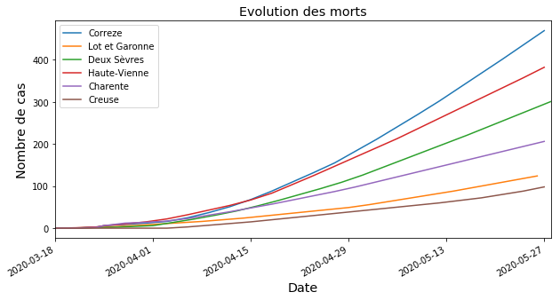

```python
somme_cor.plot(figsize=(10,5), label='Correze')
somme_lt.plot(label='Lot et Garonne')
somme_dx.plot(label='Deux Sèvres')
somme_hv.plot(label='Haute-Vienne')
somme_ch.plot(label='Charente')
somme_cz.plot(label='Creuse')

plt.legend()


plt.xlabel(u'Date', size = 'x-large')
plt.ylabel(u'Nombre de cas', size = 'x-large')
plt.title(u'Evolution des morts', size = 'x-large')
```

### Départements plus peuplés

Visualisation des courbes d'évolution du nombre de morts dans les départements les plus peuplés.

```
Text(0.5,1,u'Evolution des morts')
```

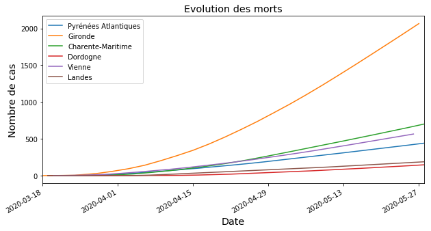

```python
somme_py.plot(figsize=(10,5), label='Pyrénées Atlantiques')
somme_gr.plot(label = 'Gironde')
somme_chm.plot(label='Charente-Maritime')
somme_Dor.plot(label='Dordogne')
somme_vn.plot(label='Vienne')
somme_ld.plot(label='Landes')

plt.legend()


plt.xlabel(u'Date', size = 'x-large')
plt.ylabel(u'Nombre de cas', size = 'x-large')
plt.title(u'Evolution des morts', size = 'x-large')
```

## Evolution des autres variables

Dans cette partie nous avons sélectionné les Pyrénées-Atlantiques, la Chaente-Maritime, la Gironde, la Corrèze et les Landes afin d'étudier leurs comportements sur les autres variables de notre dataset.

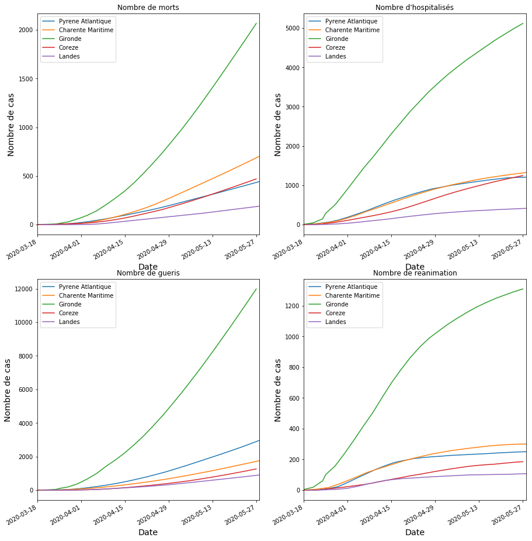

```python
plt.figure(figsize=(15,17))

plt.subplot(2,2, 1)
plt.title(u"Nombre de morts")
np.cumsum(PyreneAtlantique["Nbr_mort"]).plot(label='Pyrene Atlantique')
np.cumsum(CharenteMaritime["Nbr_mort"]).plot(label= "Charente Maritime")
np.cumsum(Gironde["Nbr_mort"]).plot(label= 'Gironde')
np.cumsum(Coreze["Nbr_mort"]).plot(label= 'Coreze')
np.cumsum(Landes["Nbr_mort"]).plot(label= 'Landes')

plt.xlabel(u'Date', size = 'x-large')
plt.ylabel(u'Nombre de cas', size = 'x-large')

plt.legend()

plt.subplot(2,2, 2)
plt.title(u"Nombre d'hospitalisés")
np.cumsum(PyreneAtlantique["Nbr_hospi"]).plot(label='Pyrene Atlantique')
np.cumsum(CharenteMaritime["Nbr_hospi"]).plot(label= "Charente Maritime")
np.cumsum(Gironde["Nbr_hospi"]).plot(label= 'Gironde')
np.cumsum(Coreze["Nbr_hospi"]).plot(label= 'Coreze')
np.cumsum(Landes["Nbr_hospi"]).plot(label= 'Landes')

plt.xlabel(u'Date', size = 'x-large')
plt.ylabel(u'Nombre de cas', size = 'x-large')

plt.legend()

plt.subplot(2,2, 3)
plt.title(u"Nombre de gueris")
np.cumsum(PyreneAtlantique["Nbr_guer"]).plot(label='Pyrene Atlantique')
np.cumsum(CharenteMaritime["Nbr_guer"]).plot(label= "Charente Maritime")
np.cumsum(Gironde["Nbr_guer"]).plot(label= 'Gironde')
np.cumsum(Coreze["Nbr_guer"]).plot(label= 'Coreze')
np.cumsum(Landes["Nbr_guer"]).plot(label= 'Landes')

plt.xlabel(u'Date', size = 'x-large')
plt.ylabel(u'Nombre de cas', size = 'x-large')

plt.legend()

plt.subplot(2,2, 4)
plt.title(u"Nombre de reanimation")
np.cumsum(PyreneAtlantique["Nbr_rea"]).plot(label='Pyrene Atlantique')
np.cumsum(CharenteMaritime["Nbr_rea"]).plot(label= "Charente Maritime")
np.cumsum(Gironde["Nbr_rea"]).plot(label= 'Gironde')
np.cumsum(Coreze["Nbr_rea"]).plot(label= 'Coreze')
np.cumsum(Landes["Nbr_rea"]).plot(label= 'Landes')

plt.xlabel(u'Date', size = 'x-large')
plt.ylabel(u'Nombre de cas', size = 'x-large')

plt.legend()
```

#### Remarques :

Il en ressort qu'en Gironde, le nombre de personnes décédées croît de manière proportionnelle au nombre de personnes guéries. Cela confirme bien que le nombre d'habitants a un rôle dans le nombre de morts dans un département. Aussi, puisque nous savons qu'en raison de certaines saturations de place en réanimations dans d'autres départements ou région, des patients ont été emmener dans ce département ce qui peut expliquer aussi le nombre croissant de personnes hospitalisées.

# Evolution des différents cas dans la région

```python
mort = NouvelleAquitaine['Nbr_mort'].cumsum()
guer = NouvelleAquitaine['Nbr_guer'].cumsum()
rean = NouvelleAquitaine['Nbr_rea'].cumsum()
hospi = NouvelleAquitaine['Nbr_hospi'].cumsum()
```

```
Text(0.5,1,'Evolution des cas en Nouvelle-Aquitaine')
```

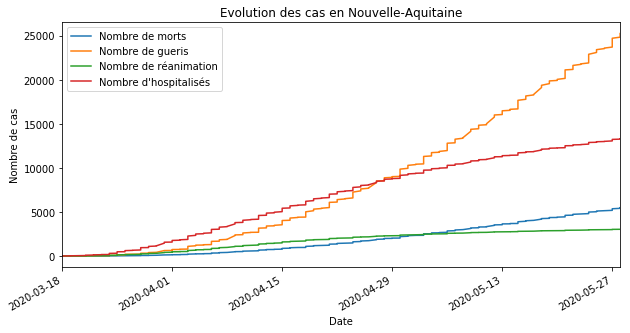

```python
mort.plot(figsize=(10,5), label='Nombre de morts')
guer.plot(label='Nombre de gueris')
rean.plot(label='Nombre de réanimation')
hospi.plot(label='Nombre d\'hospitalisés')

plt.legend()

plt.xlabel("Date")
plt.ylabel("Nombre de cas")
plt.title('Evolution des cas en Nouvelle-Aquitaine')
```

#### Remarques :

De manière générale dans la région, on voit que le nombre de personnes guéris est important alors que le nombre de morts est bien moins élevé malgré le fait qu'il continue d'avoir une tendances ascendante. La date du 29 avril est un point important puisque c'est à partir cet instant que le nombre de personnes guéries est devenu supérieur à celui des personnes hospitalisées. Quasiment une semaine après ce cap le déconfinement était prononcé en dans le pays et cela est aussi dû au fait que le nombre de personnes en réanimation avait une allure descendante.

Ces bons paramètres ont donc permit à la région d'être déconfinée en même temps que les autres.

## Sélection des dates importantes

Dans cette partie nous avons sélectionné les dates à partir des quelles l'étude nous semblait intéressante. Nous avons pour cela pris les dates de début, de milieu et de fin l'épidémie.

Cela nous permettra de comparer les résultats en Nouvelle-Aquitaine et en France de manière générale dans ces périodes précises. Cette opération pour le pays tout entier permettra d'avoir une comparaison des tendances générales.

```python
debutNouvelleAquitaine= NouvelleAquitaine[NouvelleAquitaine.index == '2020-03-18']
milieuNouvelleAquitaine= NouvelleAquitaine[NouvelleAquitaine.index == '2020-04-13']
finNouvelleAquitaine= NouvelleAquitaine[NouvelleAquitaine.index == '2020-05-15']


debutFrance =  dataFrance[dataFrance.index == '2020-03-18']
milieuFrance =  dataFrance[dataFrance.index == '2020-04-13']
finFrance =  dataFrance[dataFrance.index == '2020-05-15']
```

### Comparaison Nouvelle-Aquitaine/France

```
Text(0.5,1,u'Repartition des malades Nouvelle Aquitaine milieu \xe9pid\xe9mie')
```

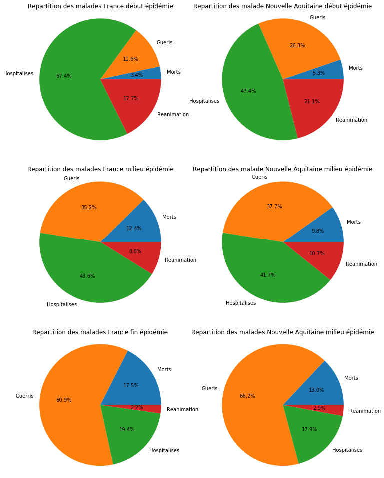

```python
plt.figure(figsize=(12,17))

plt.subplot(3,2, 1)

plt.axis('equal')

plt.pie([np.sum(debutFrance['Nbr_mort']), np.sum(debutFrance['Nbr_guer']), np.sum(debutFrance['Nbr_hospi']), np.sum(debutFrance['Nbr_rea'])], labels=["Morts", "Gueris", "Hospitalises", "Reanimation"], autopct='%1.1f%%')
plt.title(u"Repartition des malades France début épidémie")


plt.subplot(3,2, 2)

plt.axis('equal')

plt.pie([np.sum(debutNouvelleAquitaine['Nbr_mort']), np.sum(debutNouvelleAquitaine['Nbr_guer']), np.sum(debutNouvelleAquitaine['Nbr_hospi']), np.sum(debutNouvelleAquitaine['Nbr_rea'])], labels=["Morts", "Gueris", "Hospitalises", "Reanimation"],  autopct='%1.1f%%')
plt.title(u"Repartition des malade Nouvelle Aquitaine début épidémie")

plt.subplot(3,2, 3)

plt.axis('equal')

plt.pie([np.sum(milieuFrance['Nbr_mort']), np.sum(milieuFrance['Nbr_guer']), np.sum(milieuFrance['Nbr_hospi']), np.sum(milieuFrance['Nbr_rea'])], labels=["Morts", "Gueris", "Hospitalises", "Reanimation"], autopct='%1.1f%%')
plt.title(u"Repartition des malades France milieu épidémie")

plt.subplot(3,2, 4)

plt.axis('equal')

plt.pie([np.sum(milieuNouvelleAquitaine['Nbr_mort']), np.sum(milieuNouvelleAquitaine['Nbr_guer']), np.sum(milieuNouvelleAquitaine['Nbr_hospi']), np.sum(milieuNouvelleAquitaine['Nbr_rea'])], labels=["Morts", "Gueris", "Hospitalises", "Reanimation"], autopct='%1.1f%%')
plt.title(u"Repartition des malade Nouvelle Aquitaine milieu épidémie")

plt.subplot(3,2, 5)

plt.axis('equal')

plt.pie([np.sum(finFrance['Nbr_mort']), np.sum(finFrance['Nbr_guer']), np.sum(finFrance['Nbr_hospi']), np.sum(finFrance['Nbr_rea'])], labels=["Morts", "Guerris", "Hospitalises", "Reanimation"], autopct='%1.1f%%')
plt.title(u"Repartition des malades France fin épidémie")

plt.subplot(3,2, 6)

plt.axis('equal')

plt.pie([np.sum(finNouvelleAquitaine['Nbr_mort']), np.sum(finNouvelleAquitaine['Nbr_guer']), np.sum(finNouvelleAquitaine['Nbr_hospi']), np.sum(finNouvelleAquitaine['Nbr_rea'])], labels=["Morts", "Gueris", "Hospitalises", "Reanimation"],  autopct='%1.1f%%')
plt.title(u"Repartition des malades Nouvelle Aquitaine milieu épidémie")
```

#### Remarques :

Il en ressort que le nombre de personnes hospitalisées et en réanimation diminue de façon similaire dans la région et le pays. On remarque cependant qu'en début d'épidémie, le nombre de morts dans la région était supérieur à celui de la France, cela laisse à penser que la Nouvelle-Aquitaine fait partie des régions où le virus a été le plus actifs au début, puis a été progressivement maitrisé puisque la tendances s'inverse en milieu et en fin d'épidémie.

Cependant malgré le fait que le nombre de personnes hospitalisées soit plus élevé en France, dans la région on a toutefois un nombre de personnes en réanimation supérieur. Cela laisse à penser que la région aurait eu plus de cas critiques que les autres de façon générale.

# Conclusion

Cette analyse statistique de la région Nouvelle-Aquitaine montre que l'évolution des personnes décédées, en réanimation, guéris et hospitalisées suit des tendances comparables à celles de la France entière.

#### Auteurs :

Rédigé par Daniel ATANGANA, Nahia GORRICHON et Pierre VIRGAUX avec la participation de :

- BUISSON-CHAVOT Julien
- CHATRY Roxane

#### Contexte : Etude statistique sur le Covid19 en Nouvelle-Aquitaine

#### Date : 29/05/2020